# Using the natural package

Guo Yu

2018-01-15

The `natural` package contains the implementations of two methods that estimate the error variance of a high-dimensional linear model, namely, the natural lasso and the organic lasso. The details of the methods can be found in [Yu, Bien (2017) *Estimating the error variance in a high-dimensional linear model*](https://arxiv.org/abs/1712.02412). In particular, given a data matrix $X \in \mathbb{R}^{n \times p}$, with each row an observation of $p$ features, and a vector of response $\mathbf{y} \in \mathbb{R}^n$, this package implements two penalized maximum likelihood-based approaches for jointly estimating $\beta$ and $\sigma^2$ in a linear model
$$y = X \beta + \varepsilon, \quad \varepsilon \sim N(0, \sigma^2).$$
This document serves as an introduction of using the package.

## Data simulation

To reproduce the simulation study in the paper, the package also contains a function to generate random samples from a linear model with user-specified model parameters. In particular, `make_sparse_model` generates a sparse linear model as above, with $X \sim N(0, \Sigma)$ such that $\Sigma_{jj} = 1$ and $\Sigma_{ij} = \rho$. The value of columnwise correlation $\rho$ is set by the function argument `rho`. To generate $\beta$, we set the number of nonzero elements to be $\lceil n^\alpha \rceil$, where $\alpha$ is set by the argument `alpha`, and each nonzero element is drawn from a Laplace distribution of rate $1$. For a given signal-to-noise ratio, as specified by `snr`, we have error variance $\sigma^2 = \beta^T \Sigma \beta / snr$.

```r
library(natural)
set.seed(123)
nsim <- 100
sim <- make_sparse_model(n = 50, p = 300, alpha = 0.6, rho = 0.6, snr = 2, nsim = nsim)
```

## Estimating $\sigma$ with natural lasso

The main functions implementing natural lasso are `nlasso_path` and `nlasso_cv`. `nlasso_path` computes the natural lasso estimates of the error variance along a path of tuning parameters, and `nlasso_cv` selects the tuning parameter using K-fold cross-validation.

### Computing natural lasso along a path of tuning parameters

`nlasso_path` takes the design matrix and the response . It also requires a path of tuning parameters $\lambda$, and the function outputs the following three estimates:

`sig_obj_path`
$$\hat{\sigma} ^2(\lambda) = \frac{1}{n}||y - X \hat{\beta}_\lambda||_2^2 + 2 \lambda ||\hat\beta_\lambda||_1,$$
`sig_naive_path`
$$\hat{\sigma} ^2_{naive}(\lambda) = \frac{1}{n}||y - X \hat{\beta}_\lambda||_2^2,$$
and `sig_df_path` (Reid, et, al 2016)
$$\hat{\sigma}^2_{df}(\lambda) = \frac{1}{n - \hat{s}_\lambda}||y - X \hat{\beta}_\lambda||_2^2,$$
where
$$\hat{\beta}_\lambda = \arg\min \frac{1}{n} ||y - X \beta||_2^2 + 2\lambda ||\beta||_1$$
is the lasso solution with tuning parameter $\lambda$, and $\hat{s}_\lambda$ is the degree of freedom of the lasso fit.

The tuning parameter path can be specified via argument `lambda`. If not provided, the algorithm will automatically generate a path of lambda of length `nlam`. The output is a S3 object, which can be printed or plotted.

```r
nl <- nlasso_path(x = sim$x, y = sim$y[, 1])
#plot(nl)
#print(nl)
```

### Selecting the tuning parameter of natural lasso using cross-validation

The function `nlasso_cv` implements a $K$-fold cross-validation procedure to select the best tuning parameter value. The value of $K$ can be specified by the argument `nfold`. The following code does the cross-validation, plots the estimate of prediction error on the test set, and selects the best tuning parameter.

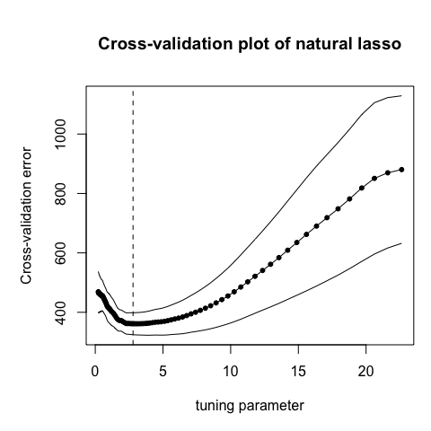

```r
nl_cv <- nlasso_cv(x = sim$x, y = sim$y[, 1])
plot(nl_cv)
```

The return of `nlasso_cv` is a list of objects. See `?nlasso_cv` for more details. In particular, `sig_obj`, `sig_naive`, and `sig_df` are the cross-validated estimates.

### Computing natural lasso with `glmnet` output

The function `nlasso_path` calls `glmnet` internally to solve lasso problems. In many use cases, one might have already called `glmnet` (and/or `cv.glmnet`) before calling `nlasso_path` and/or `nlasso_cv`. To avoid redundant computation, one can pass the output from `glmnet` into `nlasso_path` using the argument `glmnet_output`. By doing so, arguments like `lambda`, `nlam`, `flmin`, etc, will be ignored, and the function will compute estimates of $\sigma$ from `glmnet_output` directly. It is suggested that `glmnet_output` should be from `glmnet` call with argument `standardize = TRUE` (which is by default) to align with what `nlasso_path` is doing internally when `glmnet_output = NULL` (by default).

```r
library(glmnet)
g_o <- glmnet(x = sim$x, y = sim$y[, 1], lambda = nl$lambda)
nl2 <- nlasso_path(x = sim$x, y = sim$y[, 1], glmnet_output = g_o)
```

Similarly, one can pass the output from `cv.glmnet` into `nlasso_cv` with argument `glmnet_output`.

```r
g_o_cv <- cv.glmnet(x = sim$x, y = sim$y[, 1])
nl_cv2 <- nlasso_cv(x = sim$x, y = sim$y[, 1], glmnet_output = g_o_cv)
```

## Estimating $\sigma$ with organic lasso

Organic lasso is a companion method to the natural lasso. The main novelty is that the choice of tuning parameter is *pivotal*, in that it does not depend on any unknown parameter. The organic lasso estimate of the error variance is defined as
$$\tilde{\sigma}_\lambda^2 = \min_{\beta} \frac{1}{n} ||y - X\beta||_2^2 + 2 \lambda ||\beta||_1^2.$$

The main functions implementing organic lasso are `olasso_path`, `olasso_cv`, and `olasso`. In particular, `olasso_path` computes the organic lasso estimates of the error variance along a path of tuning parameters, and `olasso_cv` selects the optimal tuning parameter using a $K$-fold cross-validation procedure. The usages are the same as `nlasso_path` and `nlasso_cv`. Please see `?olasso_cv` and `?olasso_path` for more details.

The function `olasso` computes the organic lasso estimate of $\sigma$ corresponding to two pre-specified values of tuning parameters. In particular, the function outputs the organic lasso estimates with $\lambda_1 = \frac{\log p}{n}$, and $\lambda_2$, which is a Monte-Carlo estimate of the quantity $n^{-2}||X^T e||_\infty^2$, where $e$ is an n-dimensional vector of independent standard normals. We show in the following example that both of them give close estimates of the true error variance. For completeness of the comparison, we also include the outputs of `olasso_cv` and `nlasso_cv`.

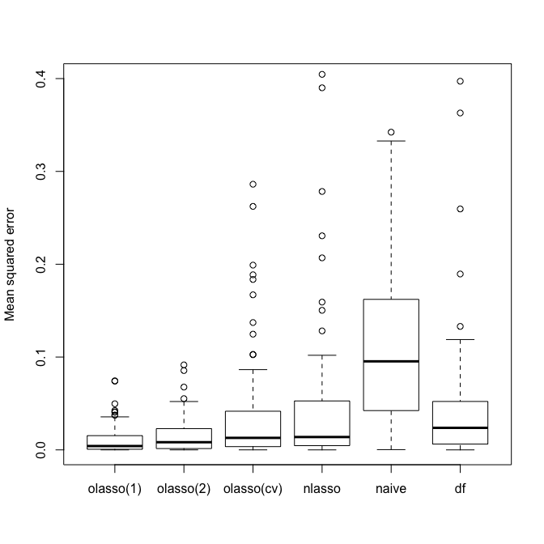

```r
err_o_mat <- matrix(NA, nrow = nsim, ncol = 6)
colnames(err_o_mat) <- c("olasso(1)", "olasso(2)", "olasso(cv)", "nlasso", "naive", "df")
for(i in seq(nsim)){
  cur_ol <- olasso(x = sim$x, y = sim$y[, i])
  err_o_mat[i, 1] <- (cur_ol$sig_obj_1 / sim$sigma - 1)^2
  err_o_mat[i, 2] <- (cur_ol$sig_obj_2 / sim$sigma - 1)^2
  cur_ol_cv <- olasso_cv(x = sim$x, y = sim$y[, i])
  err_o_mat[i, 3] <- (cur_ol_cv$sig_obj / sim$sigma - 1)^2
  cur_nl_cv <- nlasso_cv(x = sim$x, y = sim$y[, i])
  err_o_mat[i, 4] <- (cur_nl_cv$sig_obj / sim$sigma - 1)^2
  err_o_mat[i, 5] <- (cur_nl_cv$sig_naive / sim$sigma - 1)^2
  err_o_mat[i, 6] <- (cur_nl_cv$sig_df / sim$sigma - 1)^2
}
boxplot(err_o_mat, ylim = c(0, 0.4), ylab = "Mean squared error")
```